# Der Effekt von Earnings-Conference Calls am Aktienmarkt

# Motivation

Earnings Conference Calls sind zentrale Informationsereignisse in Finanzmärkten. Hier kommuniziert das Management direkt mit Investoren und Analysten über die aktuelle Geschäftslage und Zukunftsaussichten. Die finanzwirtschaftliche Forschung zeigt, dass diese Calls erhebliche Kursbewegungen auslösen können - doch die zugrundeliegenden Mechanismen sind noch nicht vollständig verstanden.

Während traditionelle Finanztheorie von effizienten Märkten ausgeht, die alle verfügbaren Informationen sofort verarbeiten, zeigen empirische Studien, dass die Art der Kommunikation und das Sentiment der Aussagen eigenständige Erklärungskraft für Aktienkursreaktionen besitzen. Diese Erkenntnisse haben direkte praktische Relevanz: Banken nutzen Sentiment-Analysen für algorithmische Handelsstrategien, Hedge Fonds entwickeln systematische Ansätze zur Textauswertung, und Asset Manager integrieren qualitative Informationen in ihre Bewertungsmodelle.

In diesem Projekt kombinieren Sie Event Studies - eine etablierte Methode der empirischen Finanzforschung zur Messung von Informationseffekten - mit modernen Large Language Models zur systematischen Textanalyse. Sie untersuchen, ob und wie sich qualitative Aussagen des Managements in quantifizierbaren Marktreaktionen niederschlagen, und lernen dabei sowohl die methodischen Grundlagen der Kausalitätsidentifikation als auch den praktischen Umgang mit KI-gestützten Finanzanalysen kennen.

# Event-Study-Methodik und theoretische Diskussion

1. Lesen Sie das Kapitel [“Event Studies” in Huntington-Klein (2021)](https://theeffectbook.net/ch-EventStudies.html) und beantworten Sie die folgenden Fragen dazu:

Kann eine Eventstudie helfen, den kausalen Effekt eines Earnings Conference Calls auf die Aktienrendite eines Unternehmens zu identifizieren? Gehen Sie bei der Beantwortung dieser Frage insbesondere auf die nachfolgenden Punkte ein:

- Welche Art von Variation nutzt eine Eventstudie zur Identifikation des Effekts?
- Welche Voraussetzung(en) müssen erfüllt sein, damit die Eventstudie eine gültige Kausalschätzung liefert?
  - Was bedeutet das “Joint-Test Problem” in diesem Kontext?

**Kann eine Eventstudie helfen, den kausalen Effekt eines Earnings Conference Calls auf die Aktienrendite eines Unternehmens zu identifizieren?**

Eine Eventstudie kann dazu beitragen, den kausalen Effekt eines Earnings Conference Calls (ECC) auf die Aktienrendite eines Unternehmens zu identifizieren, unter der Voraussetzung, dass bestimmte methodische Anforderungen erfüllt sind. Wie im Kapitel “Event Studies” von Huntington-Klein (2021) erläutert, basiert die Event-Study-Methodik auf dem Vergleich des beobachteten Verlaufs einer Zeitreihe, in diesem Fall der Aktienrendite, unmittelbar vor und nach einem eindeutig datierten Ereignis, hier dem Earnings Conference Call.

**Welche Art von Variation nutzt eine Eventstudie zur Identifikation des Effekts?**

Zur Identifikation des Effekts nutzt die Eventstudie zeitliche Variation. Es wird angenommen, dass der Zeitpunkt des Events (also des ECC) exogen ist und Veränderungen im untersuchten Outcome (der Rendite) unmittelbar als Folge des Events auftreten. Der zentrale Gedanke ist dabei, dass der Earnings Call, sofern er neue Informationen enthält, zu einer sofortigen Kursreaktion führen sollte. Diese Reaktion wird als Abweichung vom erwarteten Verlauf, dem sogenannten Counterfactual, gemessen, also von der prognostizierten Entwicklung der Rendite, wenn der Call nicht stattgefunden hätte.

**Welche Voraussetzung(en) müssen erfüllt sein, damit die Eventstudie eine gültige Kausalschätzung liefert?**

Damit eine Eventstudie eine valide Kausalschätzung liefert, müssen bestimmte Voraussetzungen erfüllt sein. Zum einen muss sichergestellt sein, dass keine anderen Ereignisse oder Schocks zeitgleich mit dem Earnings Call auftreten, die ebenfalls Einfluss auf die Rendite haben könnten, nur so kann gewährleistet werden, dass beobachtete Veränderungen auf das Event zurückzuführen sind. Zum anderen muss angenommen werden, dass sich der Kursverlauf ohne das Event auf vorhersehbare Weise fortgesetzt hätte, etwa in Form eines konstanten Trends oder eines stabilen Mittelwerts. Besonders bei kurzen Zeitfenstern rund um den Eventzeitpunkt, wie sie im finanzökonomischen Kontext häufig betrachtet werden, ist diese Annahme plausibel.

**Was bedeutet das “Joint-Test Problem” in diesem Kontext?**

Sind die erforderlichen Voraussetzungen nicht erfüllt, kann das sogenannte „Joint-Test Problem“ die Validität der Ergebnisse beeinträchtigen. Dieses Problem besteht darin, dass in einer Eventstudie die Signifikanz des Effekts des Events auf den Outcome nicht isoliert getestet werden kann, sondern nur in Kombination mit dem prognostizierten Verlauf des Counterfactuals. Das bedeutet: Ein signifikanter Effekt lässt sich nur dann als kausaler Effekt interpretieren, wenn auch das Modell zur Prognose des Counterfactuals korrekt spezifiziert ist.

Liegen diesem Modell jedoch fehlerhafte Annahmen zugrunde, kann dies dazu führen, dass ein scheinbar signifikanter Effekt nicht durch das Event selbst, sondern durch die Missspezifikation des Counterfactuals entsteht. In diesem Fall wird der beobachtete Unterschied fälschlicherweise als Kausaleffekt interpretiert.

Wird der Verlauf der Aktienrendite ohne den Earnings Conference Call nicht realistisch geschätzt, lassen sich Kausalität und statistische Signifikanz des beobachteten Effekts nicht valide beurteilen. Die Aussagekraft der Eventstudie hängt somit untrennbar von der Qualität der zugrunde liegenden Modellannahmen ab.

**Fazit**

Zusammenfassend lässt sich festhalten, dass eine Eventstudie, sofern die erforderlichen Voraussetzungen erfüllt sind, ein geeignetes Instrument sein kann, um den kausalen Effekt eines Earnings Conference Calls auf die Aktienrendite eines Unternehmens zu identifizieren. Die Methode setzt eine sorgfältig begründete Prognose des erwarteten Verlaufs ohne Event voraus sowie eine bewusste Auseinandersetzung mit potenziellen Verzerrungsquellen, insbesondere im Hinblick auf das Joint-Test Problem.

Aufgrund des kurzen Zeitfensters, in dem der Effekt von Earnings Conference Calls typischerweise auftritt und wirkt, ist die Event-Study-Methodik in diesem Kontext besonders gut anwendbar.

# Daten und Datenaufbereitung

## Finanzmarktkennzahlen

2. Sie sollten in einem ersten Schritt Finanzkennzahlen aus Datastream herunterladen. Insbesondere sollten Sie den Return Index (RI) und die Total Assets (WC02999) für alle Firmen im Euro Stoxx 600 Technology Index ( wir haben Ihnen die RIC Kürzel in der Readme bereitgestellt ) vom 01.01.2020 bis heute extrahieren.

Bitte laden Sie für den Return Index tägliche Daten herunter und für die Total Assets Quartalsdaten. Weiterhin sollten Sie den Total Return Index (RI) des Euro Stoxx 600 (RIC = .STOXX) herunterladen (auch tägliche Daten). Bitte achten Sie darauf alle Daten **in Euro** herunterzuladen.

Achten Sie darauf die RIC als eindeutige Identifikationskennung in ihren Datensatz aufzunehmen.

Das Institut für Finanzwirtschaft der Universität Ulm hat einen ausführlichen [Guide zu Datastream](https://www.uni-ulm.de/fileadmin/website_uni_ulm/allgemein/Update_Introduction_Datastream_May_2025.pdf) erstellt, der Ihnen beim Download der Daten sicherlich helfen kann.

Die Universität Ulm stellt für den Download Remote-PCs zur Verfügung, auf die Sie sich von daheim aus einloggen können. Bitte buchen Sie sich hier einen Slot um Zugriff auf diese PCs zu erhalten: https://www.uni-ulm.de/mawi/iof/lehre/proposals-for-theses/datastream-and-workspace/

Sie sollten ihre Daten in Excel herunterladen und in ihrem Projekt im Unterordner `data` abspeichern.

*Hinweis 1:* Es empfiehlt sich zwei Tabellenblätter im Excel File anzulegen, eines für die täglichen Daten und eines für die Quartalsdaten

*Hinweis 2:* Datastream ist eine Datenbank, die Kennzahlen zur Finanzlage von börsennotierten Unternehmen weltweit beinhaltet. Die Lizenzen zu Datastream an der Universität Ulm werden von der Studienkommission Wirtschaftswissenschaften und der LBBW bezahlt und die Datenbank steht allen WiWi-Studierenden frei zur Verfügung. [Nähere Informationen zu Datastream finden Sie hier](https://www.uni-ulm.de/mawi/iof/lehre/proposals-for-theses/datastream-and-workspace/) (Bitte beachten: Sie müssen im Uninetz (z.B. über VPN) eingeloggt sein um die Informationen zu sehen und um sich auf die Remote-PCs loggen zu können).

*Hinweis 3:* Bei den Total Assets müssen Sie immer das Enddatum des vorherigen Jahres nehmen für den Download, d.h. Start Date wäre 31.12.2019

3. Lesen Sie die Excel Datei, welche Sie in Aufgabe 2 erstellt haben, in R ein. Achten Sie darauf, dass diese Daten tidy und richtig formatiert sind. Joinen Sie die täglichen Daten mit den Quartalsdaten für die relevanten Firmen. Die Quartalsdaten zählen für das komplette Quartal zu dem diese hinzugemerged wurden.

Setzen Sie sich mit den Aktienkursen auseinander und beantworten folgende Fragen: - Sie wollen in Aufgabe 4 *Renditen* berechnen, warum sollten Sie Daten zum “Total Return Index” und nicht dem “Price” oder “Unadjusted Price” herunterladen? Schauen Sie sich zur Klärung dieser Frage den [Guide der Uni Ulm zu Datastream](https://www.uni-ulm.de/fileadmin/website_uni_ulm/allgemein/Update_Introduction_Datastream_May_2025.pdf) genauer an. Diesen Guide sollten sie auch für den Download der Daten heranziehen.

*Hinweis:* In dem tidy Datensatz sollten Sie eine Spalte mit dem Unternehmensidentifier (RIC), eine mit dem Datum und eine mit der Variablen (RI bzw. Total Assets) haben

Der **Total Return Index (RI)** bietet die vollständigste Abbildung der tatsächlichen Wertentwicklung einer Aktie, da er sämtliche Kapitalmaßnahmen, insbesondere Dividendenzahlungen, berücksichtigt. Er misst damit die Gesamtrendite eines Investments unter der Annahme, dass Dividenden direkt reinvestiert werden.

Der **Unadjusted Price** entspricht dem tatsächlich an der Börse gehandelten historischen Kurs. Er berücksichtigt weder Dividenden noch andere Kapitalmaßnahmen. Er eignet sich hauptsächlich zur Umsetzung von Preisfiltern (z.B. Ausschluss von Pennystocks).

Der **Price** ist ein um Aktiensplits und vergleichbare Kapitalmaßnahmen bereinigter Kurs, berücksichtigt jedoch ebenfalls keine Dividendenzahlungen. Price ist Datastreams Standard-Datentyp, aber für Renditeanalysen nicht ausreichend, da Dividenden einen zentralen Bestandteil der Gesamtrendite eines Investments darstellen.

Der **Total Return Index** ist für die Renditeberechnung **vorzuziehen**, da er die vollständige Performance einer Aktie, einschließlich Dividendenzahlungen und sonstiger Kapitalmaßnahmen, abbildet. Die Verwendung von Price oder Unadjusted Price kann hingegen zu verzerrten Eindrücken und unvollständigen Ergebnissen führen, da wesentliche Ertragskomponenten unberücksichtigt bleiben.

## Renditen berechnen

4. In ihrem Datastream-Datensatz, welchen Sie in Aufgabe 2 bereits eingelesen und in Aufgabe 3 bearbeitet haben, sind die *Total Return Indices* (RI) der größten Unternehmen aus der Tech-Branche in Europa enthalten, sowie der *Total Return Indix* des Euro Stoxx 600. Der Euro Stoxx 600 ist ein großer, diversifizierter Aktienindex in Europa in dem die 600 größten Unternehmen gelistet sind. Sie sollten den Euro Stoxx 600 als Benchmark ( Rendite des Marktes ) für ihre betrachteten Unternehmen verwenden. Bitte berechnen Sie in dieser Aufgabe die Tagesrenditen aller Einzelunternehmen als:

$$\begin{equation}
Rendite_{i,t} = \frac{RI_{i,t} - RI_{i,t-1}}{RI_{i,t-1}}
\end{equation}$$

mit i = {jedes Einzelunternehmen im Datensatz} und t = {Tag}

und des Euro Stoxx 600 als:

$$\begin{equation}
Rendite_{m,t} = \frac{RI_{m,t} - RI_{m,t-1}}{RI_{m,t-1}}
\end{equation}$$

mit m = {Euro Stoxx 600} und t = {Tag}

Prüfen Sie auf NA in den Anfangszeilen und entfernen Sie diese.

Speichern Sie die Renditen der jeweiligen Unternehmen in einer neuen Variable `Rendite` ab und die Rendite des Euro Stoxx 600 als `Marktrendite`.

5. In Aufgabe 1 hatten Sie sich bereits mit der Event-Study Methodik beschäftigt, welche Sie im weiteren Verlauf des Projektes anwenden sollen. Ein erster Schritt ist es, sogenannte *Abnormale Renditen* zu berechnen. Dies sollten Sie in dieser Aufgabe mit dem sogenannten Market-adjusted returns model tun. Bitte ziehen Sie dafür die Rendite des Marktindex von der Rendite des einzelnen Unternehmens pro Tag ab.

$$\begin{equation}
AbnormaleRendite_t = Rendite_{i,t} - Rendite_{m,t}
\end{equation}$$

Beantworten Sie dazu folgende Frage:

- Warum ist es nötig die Marktrendite ( $Rendite_{m,t}$ ) von der Rendite der Einzelaktien abzuziehen? Nutzen Sie ihre Erkenntnisse aus Aufgabe 1 zur Beantwortung dieser Frage.

**Warum ist es nötig, die Marktrendite von der Rendite der Einzelaktien abzuziehen?**

In der Eventstudie soll der kausale Effekt eines Earnings Conference Calls auf die Rendite einer Aktie identifiziert werden. Um diesen Effekt isolieren zu können, ist es wichtig, systematische Markteinflüsse herauszurechnen, die nicht mit dem Earnings Conference Call selbst zu tun haben, sondern alle Aktien gleichzeitig betreffen. Dies könnten bspw. makroökonomische Nachrichten oder Zinsentscheidungen sein. Das **Market-adjusted returns model** tut genau das: Es verwendet die Marktrenditen als Näherung für den erwarteten Verlauf der Aktie ohne Earnings Conference Calls. Die Differenz zwischen der tatsächlichen Aktienrendite und der Marktrendite ergibt dann die abnormale Rendite, die potenziell durch die Earnings Conference Calls verursacht wurde.

Das ist, wie in Aufgabe 1 beschrieben, essentiell, da die Gültigkeit der kausalen Interpretation davon abhängt, wie gut der erwartete Verlauf ohne Event modelliert ist. Wird dieser mit der Marktrendite geschätzt, nimmt man an, dass die Aktie sich wie der Markt verhalten hätte, wäre das Event nicht eingetreten. Nur so kann man den Effekt von Earnings Conference Calls vom allgemeinen Marktgeschehen trennen und das Joint-Test Problem vermeiden, das sonst zu Fehlschlüssen führen könnte.

## Earnings Call-Transkripte von LSEG Workspace einlesen

Die Basis für alle weiteren Analysen sind die Abnormalen Renditen der einzelner Unternehmen, die Sie in den vorherigen Aufgaben berechnet haben. Jedoch benötigen Sie nun noch ein Event, dessen Effekt Sie im Rahmen der Eventstudie analysieren möchten. Hier kommen die bereits in der Motivation erwähnten Earnings-Conference-Calls ins Spiel, die Sie im weiteren Verlauf des Projekts näher analysieren sollten. Die Earnings Conference Calls finden für große Unternehmen in der Regel quartalsweise statt. Manche Unternehmen halten jedoch auch nur halbjährliche Earnings Conference Calls ab und andere verzichten ganz darauf.

6. Wir haben Ihnen die Earnings Conference Calls aus LSEG Workspace für alle Firmen aus dem Euro Stoxx 600 Technology Sektor ab 2020 bis zum aktuellen Rand heruntergeladen und diese unter `data/transcripts.zip` bereitgestellt. Lesen Sie die Dateien in R ein. Ihr Datensatz sollte für jedes Transkript das RIC-Kürzel, Datum und den Text des Transkripts beinhalten, dies können Sie aus dem Namen der Datei extrahieren.

*Hinweis:* Das RIC Kürzel finden Sie im Namen der Datei (Beispiel: “2020-Jan-28-SAPG.DE-140242583050-Transcript.txt” -> “Datum-RIC-Nummer-Transcript.txt”)

Die Earnings Conference Calls laufen immer gleich ab: Zuerst spricht der CEO und meist CFO über die aktuellen Entwicklungen am Markt und wie das Unternehmen aktuell steht. Weiterhin werden Einschätzungen für die Zukunft angesprochen. Im zweiten Teil, der Q&A Sektion, dürfen Analysten Fragen an das Management stellen. Dieser Teil ist meist informativer als die vorbereiteten Statements des Managements, da die Fragen nicht vorher abgesprochen werden und das Management spontane Antworten bereithalten muss.

Sie sollen sich in diesem Projekt auf den zweiten Teil, d.h. die Q&A Section in den Earnings Conference Calls konzentrieren.

7. Analysieren Sie im ersten Schritt die Earnings Conference Calls indem Sie einige davon überfliegen. Schauen Sie explizit nach Hinweisen, ob und wie die Q&A Sektion im Text von den anderen Inhalten abgetrennt ist. Anschließend sollten Sie diese Q&A Sektion in den Earnings Conference Calls in R extrahieren, da Sie nur diese Sektion in den späteren Aufgaben analysieren sollen.

Da es vorteilhaft für ihre weitergehenden Analysen ist möglichst kompakte Texte ohne Redundanzen zu haben, sollten Sie zusätzlich die Definitionen und Disclaimer Sektion am Ende des Earnings Calls entfernen.

*Hinweis 1:* Der Anteil der Q&A Sektion an der Gesamtkonversation liegt in der Regel unter 80%. Für manche Earnings Conference Calls ist dieser Anteil höher, aber hier würde ich empfehlen nachzuschauen, ob Sie die Q&A Sektion richtig extrahiert haben. Manchmal gibt es keine Q&A Sektion, dann sollte dort auch kein Text extrahiert werden.

*Hinweis 2:* Nutzen Sie das Paket `stringr` um Textmanipulationen vorzunehmen. In diesem [Cheatsheet](https://rstudio.github.io/cheatsheets/strings.pdf) sehen Sie die Hauptanwendungen inkl. regulärer Ausdrücke, welche wichtig sind um mit Texten zu arbeiten.

8. Stellen Sie in einer Grafik anschaulich dar, wie viele Worte in einem typischen Earnings Conference Call verwendet werden und wie viel davon die Q&A Sektion einnimmt.

Beschreiben Sie ihre Grafik.

*Hinweis:* Eventuell wollen Sie hier die Verteilungen zeigen o.ä.? Entscheiden Sie selbst, welche Grafik Sie produzieren.

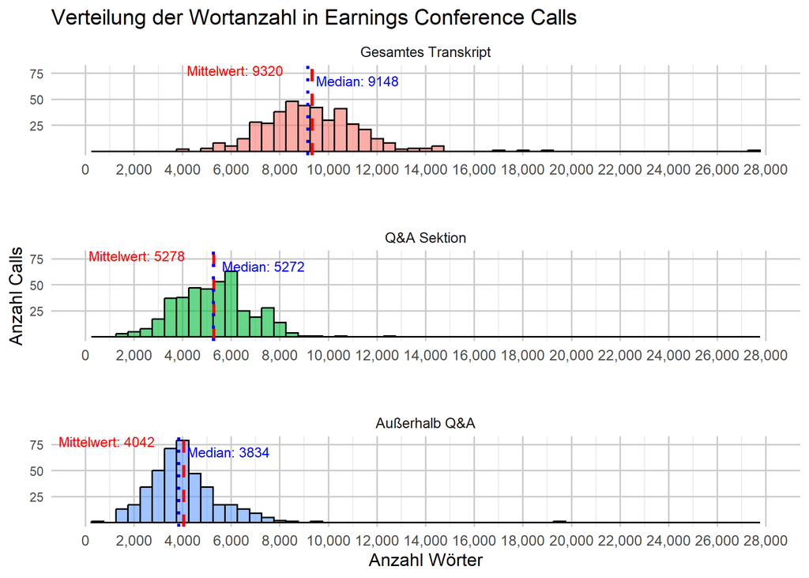

**Beschreibung**

Auffällig ist, dass die **durchschnittliche Wortanzahl** eines Earnings Conference Calls bei rund 9.300 Wörtern liegt. Etwa 45 der insgesamt 412 analysierten Calls, liegen im Bereich 9.000 bis 9.500. Der Median ist etwas geringer als der Mittelwert, wodurch sich eine leichte rechtsschiefe Verteilung ergibt. Die Schiefe dieser Verteilung liegt bei 1,89. Nur wenige Calls liegen unterhalb der 6.000-Wörter-Marke oder überschreiten die Grenze von 12.000 Wörtern. Das Maximum liegt bei rund 28.000 Wörtern, welches deutlich mehr ist als bei allen anderen Calls.

In der **Q&A-Sektion** zeigt sich, dass die durchschnittliche Wortanzahl bei etwa 5.300 Wörtern liegt. Damit macht dieser Teil im Schnitt rund 56% des gesamten Transkripts aus. Die Verteilung der Q&A-Wortanzahl ist nahezu symmetrisch verteilt, da sich der Median (etwa 5300) und Mittelwert nur minimal unterscheiden.

Im Histogramm der **Wortanzahl außerhalb der Q&A-Sektion** liegt der Mittelwert bei etwa 4.000 Wörtern, also unter dem Durchschnitt der Q&A-Sektion. Die Verteilung ist stark rechtsschief, da der Median mit rund 3800 Wörtern unter dem Mittelwert liegt und die Schiefe bei etwa 2,8 liegt. Dies bedeutet, dass die Häufigkeit der Wortanzahlen rechts vom Mittelwert schnell abnimmt, sich aber länger durchziehen, was typisch für eine rechtsschiefe Verteilung ist.

## Themenkategorien und Sentiment-Scores

Nachdem Sie nun die Earnings Conference Calls in R eingelesen und einen ersten Eindruck von deren Inhalt erhalten haben sollten Sie diese mit einem LLM (konkret mit Google Gemini) analysieren. Dafür sollten Sie einen Zero-Shot Prompt erstellen und mit Hilfe dieses Prompts die Aussage der Q&A Sektionen der Earnings Conference Calls analysieren.

9. Entwickeln Sie einen Zero-Shot Prompt für ein Large Language Model (LLM), der Earnings Conference Call Transcripts analysiert und strukturierte Sentiment-Bewertungen ausgibt. Bitte beachten Sie dabei folgende Punkte:

Zielkategorien:

- Unternehmensperformance (Finanzlage, Wachstumschancen, Unternehmensrisiken)
- Marktumfeld (Branche, Wettbewerb, externe Faktoren)

Output-Format:

- JSON-Struktur mit Sentiment-Scores von -1 (sehr negativ) bis +1 (sehr positiv)
- Keine zusätzlichen Erklärungen oder Markdown-Formatierung

Sie sollten in ihrem Prompt nach einem JSON Output verlangen (strukturiertes Format), welchen Sie mit dem Paket `jsonlite` gut in R verarbeiten können.

*Hinweis 1:* Im Anhang ist eine Erklärung für die Unterschiede zwischen einem Zero-Shot Prompt, einem One-Shot Prompt und einem Few-Shot Prompt

*Hinweis 2:* Wir haben Ihnen ein [Tutorial zusammengestellt](https://projektkurs-data-science-ulm2425.netlify.app/tutorials/zero-prompting), welches das Prompting an einem Beispiel zeigt.

Bitte analysiere den folgenden Transkripttext eines Earnings Conference Calls im Hinblick auf zwei zentrale Kategorien: Unternehmensperformance (einschließlich Aussagen zur Finanzlage, zu Wachstumschancen und Unternehmensrisiken) sowie Marktumfeld (einschließlich Wettbewerbssituation, Branchentrends und relevanter externer Faktoren). Gib für jede dieser beiden Kategorien einen numerischen Sentiment-Score zwischen -1 (sehr negativ) und +1 (sehr positiv) aus.

Die Antwort soll ausschließlich im JSON-Format erfolgen, ohne zusätzliche Erklärungen, Kommentare oder Formatierungen.

```r
sentiment_prompt <- function(text) {
sprintf('Du bist ein erfahrener Finanzanalyst, der auf die strukturierte Auswertung von Earnings Conference Calls spezialisiert ist.

Deine Aufgabe:
Führe eine objektive Sentiment-Analyse der Q&A-Sektion eines Earnings Conference Calls durch, fokussiert auf:

firmenspezifischer Sentiment (Finanzlage, Wachstumschancen, Unternehmensrisiken)

Marktsegment (Wettbewerb, Branchentrends, externe Faktoren)

Analyse:
Verwende für die Sentiment Scores eine Skala von -1 (sehr negativ) bis +1 (sehr positiv). Es können alle Zwischenwerte innerhalb dieses Bereichs genutzt werden, um Nuancen abzubilden, z. B.:

- 1.0 (sehr negativ)

- 0.5 (negativ)

0.0 (neutral)

0.5 (positiv)

1.0 (sehr positiv)

Bsp. Positiv:  „Rekordumsatz in Q2 mit übertroffenen Margenzielen“
Bsp. Negativ: "Nachfrage sinkt wegen branchenspezifischer Schwäche und Kostendruck"

Format:
Gib ausschließlich genau dieses JSON zurück, ohne zusätzliche Zeichen, Leerzeilen, Erklärungen, Einleitungen, Formatierungen oder Codeblöcke:

{
"firmensentimente": 0.0,
"marktsentiment": 0.0,
"KONFIDENZ": 0.0
}

Die Werte im Beispiel sind Platzhalter und müssen durch deine Analyse ersetzt werden.
Die JSON-Ausgabe muss maschinenlesbar und parsebar sein, ohne Anführungszeichen um numerische Werte. Dieses exakte Format ist für die Weiterverarbeitung zwingend erforderlich.

Falls der erhaltene Text NA ist oder keinen verwertbaren Inhalt enthält, gib folgendes JSON zurück:

{
"firmensentimente": "NA",
"marktsentiment": "NA",
"KONFIDENZ": "NA"
}

Text zur Analyse: %s', text)
}
```

10. Im nächsten Schritt sollten Sie sich in das Paket [`ellmer`](https://ellmer.tidyverse.org/) einarbeiten. Durch `ellmer` erhalten Sie Zugriff auf alle gängigen LLMs mittels R über einen API Zugang. Wir haben ihnen für dieses Projekt ein Google Konto pro Gruppe erstellt und den API Schlüssel für jede Gruppe in das dazugehörige Repo (Readme) gepushed.
- Lesen Sie sich in das [`ellmer`](https://ellmer.tidyverse.org/) Paket ein und wie Sie den API Schlüssel für Google Gemini in ihrer .Renviron Datei hinterlegen können
- Untersuchen Sie die unterschiedlichen Modelle, die Google zur Verfügung stellt und deren Ratelimits: https://ai.google.dev/gemini-api/docs/models?hl=de

Bitte beantworten Sie folgende Fragen:

- Was sind die Vorteile/Nachteile der einzelnen Google Modelle?
- Welches (kostenlose) Modell würden Sie für ihre aktuellen Analysen bevorzugt einsetzen? Begründen Sie!
- Welche Möglichkeiten haben Sie, nicht in die Ratelimits zu kommen?
- In `ellmer` können Sie mittels dem [`params()`](https://www.tidyverse.org/blog/2025/05/ellmer-0-2-0/#parameters) Parameter auch die Temperatur ihres Modells einstellen. Was ist mit der Temperatur gemeint und was sind die Vorteile/Nachteile einer niedrigen Temperatur?

**Vorteile und Nachteile der einzelnen Google Modelle:**

Die verschiedenen Google Gemini-Modelle unterscheiden sich in ihrer Leistungsfähigkeit, Funktionalität und Einsatzmöglichkeiten. Neuere Modelle wie Gemini 2.5 Flash bieten fortschrittliche Fähigkeiten, unterstützen Multimodalität (Text, Audio, Video) und haben Funktionen wie „Denken“ (erweitertes reasoning) und Funktionsaufrufe, sind jedoch bei den Ratenlimits oft eingeschränkt und bieten keine strukturierte Ausgabe oder Caching. Gemini 2.5 Flash Live erlaubt neben Multimodalität auch strukturierte Ausgaben und Codeausführung, ist aber bei gleichzeitigen Sessions limitiert. Das Modell Gemini 2.0 Flash überzeugt vor allem durch sein sehr großes Kontextfenster von über einer Million Tokens, unterstützt strukturierte Ausgaben, Funktionsaufrufe, Codeausführung und Suche, bietet jedoch keine Audiogenerierung. Die Lite-Version dieses Modells ist für kosteneffiziente und latenzarme Anwendungen optimiert, mit ähnlichen Funktionalitäten, jedoch ohne Codeausführung und Suche. Ältere Modelle wie Gemini 1.5 Flash sind noch sehr vielseitig und bieten JSON-Unterstützung sowie Caching, haben aber kleinere Kontextfenster und weniger Rechenleistung.

**Welches (kostenlose) Modell würden Sie für aktuelle Analysen bevorzugt einsetzen und warum?**

Für aktuelle Analysen im kostenlosen Bereich würde ich Gemini 2.0 Flash oder 2.5 Flash bevorzugen. Diese Modelle bieten ein sehr großes Kontextfenster von über einer Million Tokens, was besonders wichtig ist, wenn umfangreiche Textdaten verarbeitet werden sollen. Zudem unterstützen diese strukturierte Ausgaben, Funktionsaufrufe und Codeausführung, wodurch komplexe und automatisierte Analysen einfacher umzusetzen sind. Die vergleichsweise großzügigen Ratenlimits von 15 und 10 Anfragen pro Minute und 1 Million Tokens pro Minute bei dem 2.0 Flash Modell ermöglichen eine intensive Nutzung ohne schnelle Limitüberschreitungen. Dadurch sind Gemini 2.0 Flash und 2.5 Flash für vielseitige, datenintensive Textanalysen optimal geeignet.

**Welche Möglichkeiten gibt es, nicht in die Ratelimits zu kommen?**

Um nicht in Ratenlimits zu geraten, sollte man Anfragen zeitlich so steuern, dass das Limit der Anfragen pro Minute nicht überschritten wird. Außerdem hilft es, Eingaben so kompakt wie möglich zu halten, um das Token-Limit nicht zu überschreiten. Das Zwischenspeichern von Antworten (Caching), wenn vom Modell unterstützt, reduziert die Anzahl wiederholter Anfragen. Bei wachsendem Bedarf ist ein Upgrade auf höhere Nutzungsstufen sinnvoll, da diese deutlich höhere Limits bieten. Schließlich hilft es, parallele Sessions und unnötige Anfragen zu vermeiden, um die verfügbaren Ressourcen effizient zu nutzen.

**Was ist mit der Temperatur gemeint und was sind die Vorteile/Nachteile einer niedrigen Temperatur?**

Die „Temperatur“ ist ein Parameter, der steuert, wie kreativ oder deterministisch ein Sprachmodell bei der Textgenerierung vorgeht. Bei einer niedrigen Temperatur, etwa zwischen 0 und 0,3, wählt das Modell überwiegend die wahrscheinlichsten Wörter und produziert dadurch sehr vorhersehbare und konsistente Antworten. Dies ist besonders vorteilhaft bei Aufgaben, die präzise und verlässliche Ergebnisse erfordern, wie beispielsweise bei analytischen oder wissenschaftlichen Anwendungen. Durch die geringe Variabilität verringert sich zudem die Wahrscheinlichkeit für „Halluzinationen“ oder unsinnige Ausgaben. Allerdings kann eine niedrige Temperatur dazu führen, dass die Antworten weniger abwechslungsreich und kreativ sind, was in manchen Situationen als monoton oder weniger flexibel wahrgenommen wird. Insgesamt ist eine niedrige Temperatur empfehlenswert, wenn Genauigkeit und Reproduzierbarkeit im Vordergrund stehen und weniger Wert auf kreative Vielfalt gelegt wird.

11. Nutzen Sie ihren in Aufgabe 9 erstellten Prompt mit dem `ellmer` Paket und ihrem Google API-Key um alle 431 Earnings Conference Call Transkripte zu analysieren. Nutzen Sie für ihre Analyse das Modell Google Gemini 2.0-flash oder Google Gemini 2.5-flash.

Speichern Sie die Ergebnisse ihrer Analyse in einem strukturierten Tibble ab. Anschließend sollten Sie den Datensatz auch unter `data/sentiment.Rds` abspeichern.

Stellen Sie ihre Ergebnisse in einer Tabelle dar und beschreiben diese kurz:

- Wie ist der Mittelwert, Standardabweichung und Median der Einschätzung bezüglich Unternehmensperformance und Marktumfeld in ihren Earnings Conference Calls?

*Hinweis 1:* Achten Sie darauf nicht bei jedem Knitten die Analyse neu zu starten, sondern setzen Sie den Chunk dieser Aufgabe auf `eval = FALSE` und lassen Sie die Analyse nur einmal durchlaufen und speichern Sie die Ergebnisse ab (und laden diese später um damit weiterarbeiten zu können)

*Hinweis 2:* Achten Sie auf ihre Ratelimits und beanspruchen Sie den API Zugriff nicht zu stark, z.B. durch den Einbau von “sleep”-Zeiten in ihrem Code

Sentiment-Statistik für Unternehmensperformance und Marktumfeld

| Kategorie | Mittelwert | Standardabweichung | Minimum | 25% Quantil | Median | 75% Quantil | Maximum |
| --- | --- | --- | --- | --- | --- | --- | --- |
| Unternehmensperformance | 0.533 | 0.297 | -0.60 | 0.4 | 0.6 | 0.7 | 0.9 |
| Marktumfeld | 0.285 | 0.313 | -0.75 | 0.2 | 0.3 | 0.5 | 0.9 |

**Beschreibung**

Die Sentiment-Statistik zeigt eine Bewertung der Analystengespräche in Bezug auf Unternehmensperformance und das Marktumfeld, basierend auf einer Skala von -1 (sehr negativ) bis +1 (sehr positiv). Bei der Unternehmensperformance zeigt sich ein Mittelwert von 0.533, was darauf schließen lässt, dass die Unternehmensperformance in den Earnings Calls moderat positiv eingeschätzt wird. Die Hälfte aller Bewertungen liegt über 0.6 - das Sentiment ist also tendenziell optimistisch. Die Standardabweichung von 0.297 zeigt, dass die Bewertungen moderat stark streuen, was auf gewisse Unterschiede in der wahrgenommenen Unternehmenslage hindeutet, etwa bedingt durch unterschiedliche Geschäftsentwicklungen, Branchenzugehörigkeiten oder regionale Marktbedingungen. Außerdem interessant ist ein Blick auf die Quantile: 50% der Werte liegen im Bereich von 0.4 bis 0.7, was auf eine robuste Mitte mit positiver Tendenz hinweist.

Beim Marktumfeld lässt sich ein Mittelwert von 0.285 ablesen. Dies deutet darauf hin, dass die Einschätzung des Marktumfelds im Schnitt verhaltener ausfällt als die Einschätzung der Unternehmensperformance. Auch hier lässt sich wieder eine hohe Streuung von 0.313 erkennen, was auf größere Unsicherheiten in der Einschätzung des Marktumfelds hindeutet, etwa infolge makroökonomischer Volatilität, geopolitischer Risiken oder branchenspezifischer Unterschiede in der Betroffenheit durch externe Einflüsse. Das Sentiment reicht von sehr pessimistischen Einschätzungen (-0.75) bis zu sehr optimistischen Einschätzungen (0.9), was auf unterschiedliche Branchenbedingungen oder externe Faktoren hindeutet.

**Fazit**

Insgesamt zeigt sich, dass die eigene Unternehmenslage vom Management im Schnitt optimistischer eingeschätzt wird, als das externe Marktumfeld. Die größere Streuung und der tiefere Durchschnitt beim Marktumfeld deuten auf eine höhere Unsicherheit hinsichtlich makroökonomischer und branchenbezogener Einflüsse hin.

Sie haben in der vorherigen Aufgabe die Stimmung bezüglich der Kategorien Unternehmensperformance und Marktperformance in den Earnings Conference Calls bestimmt. Eine Frage wäre, ob sich diese Stimmung über die Zeit hinweg verändert hat. In der folgenden Aufgabe sollen Sie sich die durchschnittliche Stimmung in diesen zwei Kategorien für die einzelnen Jahre in ihrem Datensatz näher anschauen.

12. Erstellen Sie eine geeignete Grafik um die Stimmung *aller Earnings Conference Calls eines Jahres* zu visualisieren. Tragen Sie separat die Stimmung bezüglich Unternehmensperformance und Marktumfeld ab.

Beschreiben Sie ihre Grafik.

Interpretieren Sie diese Grafik, insbesondere im Hinblick auf die gesamtwirtschaftlichen Ereignisse der letzten fünf Jahre. Hätten Sie die Ergebnisse in dieser Art erwartet?

*Hinweis:* Sie sollten sich hier eine sinnvolle Grafik überlegen, welche die Stimmungslage über die Zeit gut darstellt.

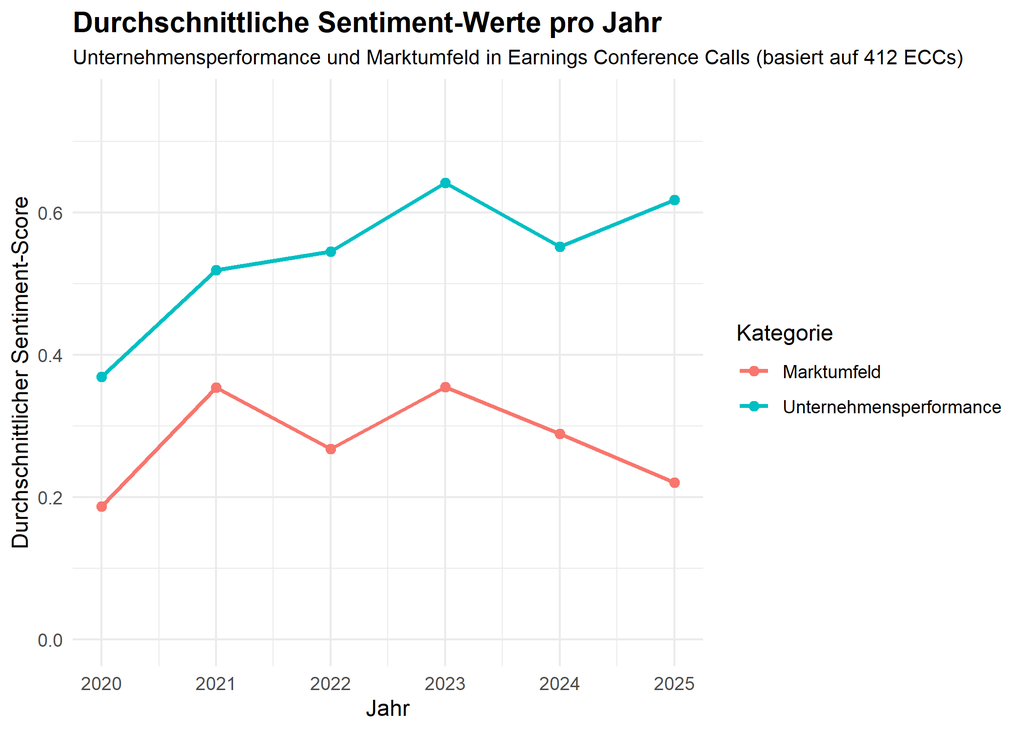

**Beschreibung**

Die Grafik zeigt die durchschnittliche Stimmung in den Earnings Conference Calls der Jahre 2020 bis 2025, getrennt nach den Kategorien Marktumfeld (MU), welche durch eine rote Linie dargestellt wird, und Unternehmensperformance (UP), welche durch die blaue Linie dargestellt wird. Die Werte bewegen sich im positiven Bereich, wobei die Unternehmensperformance durchgehend positiver bewertet wird als das Marktumfeld.

Im Jahr 2020 sind die Werte für beide Kategorien mit MU = 0,19 und UP = 0,38 vergleichsweise niedrig. Im Jahr 2021 steigen die Werte auf MU = 0,35 und UP = 0,52 an. Zwischen 2022 und 2023 stabilisiert sich die Unternehmensperformance auf einem durchweg positiven Niveau. Gleichzeitig zeigt das Marktumfeld ab 2023 eine Abwärtsbewegung.

**Interpretation**

Die niedrigen Werte im Jahr 2020 spiegeln die starke wirtschaftliche Unsicherheit und die gravierenden Folgen der Corona-Pandemie wider, die viele Branchen hart getroffen hat. Der Anstieg im Jahr 2021 zeigt die Aufhebung vieler Einschränkungen und die beginnende wirtschaftliche Erholung.

Die Abwärtsbewegung des Marktumfelds ab 2023 lässt sich durch Anzeichen von Stagnation oder Rezession in zahlreichen Volkswirtschaften erklären. Ursachen hierfür sind unter anderem steigende Inflationsraten, Energiekrisen infolge geopolitischer Spannungen, beispielsweise durch den Krieg in der Ukraine, sowie anhaltende Lieferkettenprobleme.

Trotz der schwieriger werdenden externen Rahmenbedingungen bleibt die Unternehmensperformance stabil und positiv bewertet. Dies deutet darauf hin, dass viele Unternehmen ihre finanzielle Lage und Wachstumschancen weiterhin optimistisch einschätzen – möglicherweise aufgrund erfolgreicher Anpassungen der Geschäftsstrategien und einer gewissen Resilienz.

Zusammenfassend zeigt die Grafik eine realistische Entwicklung: Die pandemiebedingte Krise 2020, die anschließende Erholung, und die seit 2023 zunehmenden Sorgen bezüglich des externen Marktumfelds angesichts globaler Herausforderungen. Diese Beobachtungen entsprechen den tatsächlichen wirtschaftlichen Ereignissen der letzten Jahre und unterstreichen die Sinnhaftigkeit der Sentiment-Analyse im Kontext von Earnings Calls.

# Eventstudie

Um zu evaluieren, ob die Earnings Conference Calls tatsächlich einen Einfluss auf die Aktienkurse der einzelnen Unternehmen hatten können Sie eine sogenannte Eventstudie durchführen, welche Sie bereits in Aufgabe 1 kennen gelernt haben. Bei einer Eventstudie betrachten Sie nur die Zeit (bei uns die Tage) unmittelbar vor oder nach einem Event. In diesem Projekt ist ein Event ein Earnings Conference Call des jeweiligen Unternehmens. Sie sollen in diesem Projekt herausfinden, wie sich über alle Unternehmen hinweg die Earnings Conference Calls auf die Aktienrenditen auswirken.

13. Verbinden Sie den Datensatz über die *Stimmung der Earnings Conference Calls (sentiment.Rds)* zu den einzelnen Unternehmen mit den *abnormalen Renditen* und speichern diesen Datensatz als `gesamtdatensatz` in R ab. Sie können das RIC-Kürzel und Datum für den Join verwenden. Sollte der Earnings Conference Call an keinem Handelstag stattgefunden haben, so joinen Sie bitte mit dem darauffolgenden Handelstag.
- Für die Tage an denen ein Earnings Conference Call stattgefunden hat sollten Sie eine Variable `event` generieren, welche an dem Tag des Calls gleich 0 ist.
- Für die Tage vor dem Earnings Conference Call (Event) sollte die Variable `event` rückwärts zählen (bis zu -5). Für alle Tage nach dem Event sollte die Variable `event` fortgeführt werden (bis +5).
- Erstellen Sie eine Variable `ar_505`, welche die *abnormalen Rendite* von Tag -5 bis +5 **fortlaufend** aufsummiert
- Erstellen Sie eine Variable `car_101`, welche die kumulierte abnormale Rendite im Zeitraum -1 bis +1 um das Event beinhaltet
- Erstellen Sie weiterhin diese sechs neuen Variablen:
  - `negativ_firm` = Wenn die Unternehmensperformance als negativ eingeschätzt wird
  - `neutral_firm` = Wenn die Unternehmensperformance als neutral eingeschätzt wird
  - `positiv_firm` = Wenn die Unternehmensperformance als positiv eingeschätzt wird
  - `negativ_market` = Wenn die Marktperformance als negativ eingeschätzt wird
  - `neutral_market` = Wenn die Marktperformance als neutral eingeschätzt wird
  - `positiv_market` = Wenn die Marktperformance als positiv eingeschätzt wird
- Erstellen Sie Dummy Variablen, die 1 sind für ein bestimmtes Jahr. Bspw. eine Dummyvariable die 2020 heißt und für alle Beobachtungen im Jahr 2020 sollte diese Variable 1 sein, 0 sonst. Tun Sie dies für alle Jahre in ihrem Datensatz

*Hinweis:* Die Funktion cumsum() könnte für diese Aufgabe hilfreich sein

14. Erstellen Sie je ein Liniendiagramm für die von ihnen betrachteten Unternehmen: Eines für die Stimmung bezüglich der Unternehmensperformance und eines bezüglich der Marktperformance.

Sie sollten in ihren Grafiken die kumulierten Renditen im Zeitraum [-5,5] Tage um einen Earnings Conference Call darstellen. - Die Variable “Event” sollte die Tage vor und nach dem Earnings Conference Call enthalten ([-5,5]) und auf der x-Achse dargestellt werden - Die Variable `ar_505` sollte die durchschnittliche kumulierte abnormale Rendite für den jeweiligen Tag auf der y-Achse abtragen (für alle Unternehmen in ihrem Datensatz) - In jeder Grafik sollten Sie eine extra Linie zeichnen für Earnings Conference Calls mit einer positiven/negativen und neutralen Stimmung und deren Einfluss auf den Aktienmarkt

Beschreiben und interpretieren Sie ihre Grafik. Gehen Sie hierbei insbesondere darauf ein, welche Erwartungen Sie auf der Basis ihrer Lektüre aus Aufgabe 1 hatten und in wie weit diese Erwartungen sich erfüllt haben.

*Hinweis:* In diesen Grafiken stellen Sie nicht jedes Event (d.h. die Auswirkungen eines jeden Earnings Conference Calls) einzeln dar, sondern gesamt für alle Earnings Conference Calls.

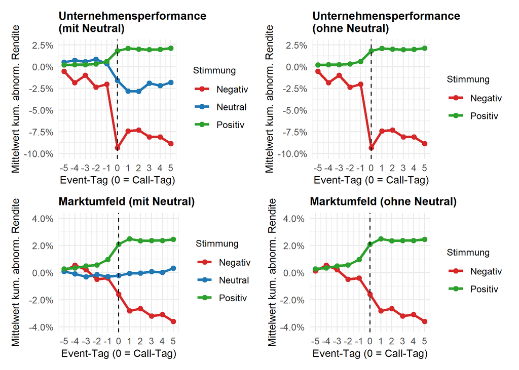

**Beschreibung der Grafiken**

Die vier Grafiken zeigen die Entwicklung der durchschnittlichen kumulierten abnormalen Renditen (CAR) von fünf Tagen vor bis fünf Tage nach dem Earnings Conference Call (Event-Tag 0). Die oberen Grafiken differenzieren nach der Stimmung zur Unternehmensperformance, die unteren beiden Grafiken nach der Stimmung zum Marktumfeld. In den Grafiken 1 und 3 (links) sind die Stimmungen in drei Kategorien eingeteilt: positiv, neutral und negativ, in den Grafiken 2 und 4 (rechts) wurde die Gruppe neutral nicht berücksichtigt, um die Ergebnisse nochmals etwas übersichtlicher darzustellen. Auf der X-Achse sind die Event-Tage von −5 bis +5 aufgetragen, die Y-Achse zeigt die jeweiligen durchschnittlichen CAR in Prozentpunkten.

In Grafik 1 und 2 ist deutlich zu erkennen, dass bei negativer Stimmung die CAR bereits am Tag des Calls (Tag 0) drastisch sinken auf etwa -10% und sich in Folge auf diesem niedrigen Niveau halten. Bei positiver Stimmung steigen die CAR an dem Call-Tag und erreichen ab etwa Tag +1 ein Maximum zwischen ungefähr 2% und 2,5%. Neutrale Stimmungen zeigen außerdem einen Zusammenhang mit negativen Renditeentwicklungen auf - die durchschnittlichen kumulierten abnormalen Renditen fallen direkt am Call Tag in den negativen Bereich und halten sich dort bei etwa - 2%.

**Interpretation der Ergebnisse**

Die Analyse der Unternehmensperformance verdeutlicht, dass die im Earnings Call geäußerte Stimmung wahrscheinlich einen deutlichen Einfluss auf die Aktienkurse hat. Die deutlichen Kursverluste bei negativer Stimmung von bis zu −10 % innerhalb weniger Tage legen nahe, dass Investoren schlechte Nachrichten als stark wertmindernd für das Unternehmen bewerten. Positive Nachrichten führen, falls Kausalität besteht, hingegen zu moderaten Kursgewinnen von etwa +2 %, diese bleiben auf konstantem Niveau. Dies deutet darauf hin, dass negative Informationen stärker verarbeitet werden als positive, ein typisches Beispiel für den sogenannten „Bad News Bias“. Neutrale Stimmungen verursachen kaum bis leicht negative Kursreaktionen, was darauf schließen lässt, dass Investoren vor allem klare Signale als relevant ansehen, jedoch auch im neutralen Fall Schwankungen bestehen.

Im Gegensatz dazu sind die Effekte der Stimmung zum Marktumfeld in der Grafik weniger ausgeprägt. Negative Aussagen führen zwar ebenfalls zu Kursverlusten (bis −3,5 %), diese fallen aber deutlich schwächer aus als bei der Unternehmensperformance. Positive Einschätzungen führen zu moderaten Renditegewinnen von bis zu +2,5 %. Dies unterstreicht, dass unternehmensspezifische Informationen für die Bewertung entscheidender sind, externe Markteinschätzungen jedoch ebenfalls eine Rolle spielen.

Diese Ergebnisse bestätigen die aus der Literatur erwarteten Muster: Earnings Calls transportieren relevante Informationen, die von Investoren schnell aufgenommen und in Kursbewegungen umgesetzt werden. Besonders die stärkeren Reaktionen auf negative gegenüber positiven Nachrichten entsprechen der empirisch belegten Asymmetrie in der Informationsverarbeitung der Märkte.

**Erwartungen nach Nummer 1**

Eine Eventstudie soll den kausalen Effekt eines Earnings Conference Calls auf die Aktienrendite identifizieren, indem sie die zeitliche Variation unmittelbar um den Eventzeitpunkt nutzt. Voraussetzung dafür ist, dass keine anderen zeitgleich wirkenden Ereignisse die Rendite beeinflussen und dass das Counterfactual – also der erwartete Kursverlauf ohne das Event – korrekt modelliert ist. Das „Joint-Test Problem“ weist darauf hin, dass die Validität der Kausalschätzung davon abhängt, dass sowohl die Wirkung des Events als auch die Modellannahmen unabhängig voneinander realistisch sind. Andernfalls können falsche Modellannahmen zu irreführenden Kausalaussagen führen.

# Regressionen

Sie haben bisher den Einfluss der Earnings Conference Calls auf die Aktienrendite der größten europäischen Unternehmen im Technologie-Sektor visuell betrachtet. Im letzten Abschnitt dieser Projektarbeit analysieren Sie ihre Daten mittels linearer Regressionen.

15. In dieser Aufgabe sollten Sie zwei Regressionen erstellen:

Regressieren Sie die kumulierten abnormalen Renditen um das Event `car_101` auf die Dummyvariablen

- `negativ_firm` und `negativ_market` in der ersten Regression und
- `positiv_firm` und `positiv_market` in der zweiten Regression.

Diese Dummyvariablen geben die Stimmung in den Earnings-Conference Calls wieder.

Beschreibung und interpretieren Sie ihre Regressionsergebnisse und gehen Sie dabei auch auf folgende Fragen ein:

- Was ist die Vergleichsgruppe in den beiden Regressionen?
- Was sind die Voraussetzungen für eine kausale Interpretation der Koeffizienten. Sind diese ihrer Meinung nach gegeben?

|  | Regressionsergebnisse Negativ | Regressionsergebnisse Positiv |
| --- | --- | --- |
| Achsenabschnitt | 0.014** | -0.042** |
|  | (0.005) | (0.013) |
| Negative Firmfaktoren | -0.053* |  |
|  | (0.027) |  |
| Negativer Markt | -0.019 |  |
|  | (0.021) |  |
| Positive Firmfaktoren |  | 0.055*** |
|  |  | (0.015) |
| Positiver Markt |  | 0.007 |
|  |  | (0.010) |
| Num.Obs. | 397 | 397 |
| AIC | -767.8 | -778.1 |
| BIC | -751.8 | -762.2 |
| Log.Lik. | 387.880 | 393.060 |

* p < 0.05, ** p < 0.01, *** p < 0.001

**Beschreibung & Interpretation der Regressionsergebnisse**

Die vorliegenden Regressionen analysieren den Einfluss der Stimmung in Earnings Conference Calls auf die kumulierten abnormalen Renditen (CAR) im Zeitraum von einem Tag vor bis einen Tag nach dem jeweiligen Call. Dabei wurden zwei separate Modelle betrachtet: eines für negative und eines für positive Stimmungen, jeweils differenziert nach den Kategorien Unternehmensperformance und Marktumfeld.

**Im Modell für positive Stimmung** zeigt sich, dass positive Firmfaktoren einen signifikant positiven Einfluss auf die Renditen ausüben (Koeffizient 0,055, p < 0,001). Dies bedeutet, dass positive Aussagen zur Unternehmensperformance mit einer Steigerung der kumulierten abnormalen Renditen einhergehen. Auch positive Marktstimmung wirkt sich positiv aus, wenn auch mit einem geringeren Effekt (0,007). Dies lässt vermuten, dass Investoren eher auf positive Signale der Unternehmen selbst reagieren als auf generelle Marktbewertungen. Der Intercept in diesem Modell liegt bei −0,042 und ist ebenfalls signifikant (p < 0,01). Der negative Intercept legt nahe, dass in Abwesenheit positiver Aussagen eine leicht negative Kursreaktion zu beobachten ist.

**Voraussetzungen für eine kausale Interpretation**

Für eine kausale Interpretation der Koeffizienten müssten mehrere Voraussetzungen erfüllt sein. Insbesondere sollte das Ereignis (der Earnings Call mit spezifischer Stimmung) exogen sein, das heißt unabhängig von anderen simultanen Einflussfaktoren auf die Aktienrendite. Außerdem sollten keine systematischen Verzerrungen durch unbeobachtete Drittvariablen vorliegen, die sowohl Stimmung als auch Rendite beeinflussen. Schließlich ist die richtige zeitliche Abfolge entscheidend: Die Stimmung muss vor der Renditeentwicklung bekannt sein, was hier durch die Event-Studien-Methodik gegeben ist.

**In der Praxis ist jedoch Vorsicht geboten:** Unternehmens- und Marktstimmung könnten simultan mit anderen Informationen oder Ereignissen auftreten, die ebenfalls die Aktienkurse beeinflussen. Zudem ist es möglich, dass Anleger die Stimmung antizipieren oder dass weitere externe Schocks den Effekt verzerren. Ohne zusätzliche Kontrollvariablen oder Instrumente zur Identifikation ist eine reine Kausalinterpretation daher eingeschränkt.

Aus meiner Sicht liefert die Analyse wichtige Hinweise auf den Zusammenhang zwischen der Stimmung in Earnings Conference Calls und den Kursreaktionen. Eine eindeutige kausale Interpretation der Wirkung der Stimmung auf die Rendite ist jedoch nur mit Einschränkungen möglich, da potenzielle Störfaktoren und simultane Ereignisse den Effekt beeinflussen können. Ohne zusätzliche Kontrollvariablen oder geeignete Identifikationsstrategien bleibt die Kausalität begrenzt.

16. In ihrer deskriptiven Analyse haben Sie bereits gesehen, dass die Unternehmen, die Sie in diesem Projekt betrachten, alle unterschiedlich groß sind. Weiterhin haben Sie gesehen, dass es ein unterschiedliches Stimmungsbild in den Calls über die einzelnen Jahre hinweg gibt. Dafür möchten Sie in ihren Regressionen nun kontrollieren.
    1. Regressieren Sie die `car_101` auf die Variablen *negativ_firm* und *negativ_market* und kontrollieren Sie auf die Größe des jeweiligen Unternehmens, indem Sie die Variable *Total_Assets* in ihre Regression aufnehmen
    2. Fügen Sie in einer zweiten Analyse zusätzlich zu den Variablen aus der 1. Regression auch noch Dummyvariablen für die Jahre in dem das Event stattgefunden hat ihrer Regression hinzu.
    3. Führen Sie die Regressionen aus 1. und 2. auch für die Variablen *positiv_firm* und *positiv_market* anstatt *negativ_firm* und *negativ_market* durch, sodass Sie am Ende 4 Regressionen haben

Beschreiben und interpretieren Sie ihre Ergebnisse im Hinblick auf die Größe der Koeffizienten und deren Signifikanz. Gehen Sie insbesondere auf folgende Fragen ein:

- Warum sollte ihre Regression nicht fünf Dummyvariablen, je eine für jedes Jahr, sondern nur vier beinhalten?
- Verändert sich durch die Dummyvariablen der Koeffizient von *negativ_firm* und *negativ_market* bzw. *positiv_firm* und *positiv_market*?
- Hätten Sie eine Veränderung des Koeffizienten von *negativ_firm*, *negativ_market*, *positiv_firm* oder *positiv_market* erwartet? Begründen Sie ihre Antwort mit ihren deskriptiven Analysen.

|  | Abhängige Variable: kumulierte abnormale Renditen Negativ | Abhängige Variable: kumulierte abnormale Renditen Negativ mit Jahreskontrollen | Abhängige Variable: kumulierte abnormale Renditen Positiv | Abhängige Variable: kumulierte abnormale Renditen Positiv mit Jahreskontrollen |
| --- | --- | --- | --- | --- |
| Negative Firmfaktoren | -0.028 | -0.027 |  |  |
|  | (0.027) | (0.027) |  |  |
| Negativer Markt | -0.057** | -0.054* |  |  |
|  | (0.022) | (0.023) |  |  |
| Positive Firmfaktoren |  |  | 0.053*** | 0.052*** |
|  |  |  | (0.016) | (0.016) |
| Positiver Markt |  |  | 0.012 | 0.014 |
|  |  |  | (0.011) | (0.011) |
| Total Assets | 0.000 | 0.000 | 0.000 | 0.000 |
|  | (0.000) | (0.000) | (0.000) | (0.000) |
| 2021 |  | -0.009 |  | -0.016 |
|  |  | (0.015) |  | (0.015) |
| 2022 |  | 0.004 |  | -0.003 |
|  |  | (0.015) |  | (0.015) |
| 2023 |  | 0.004 |  | -0.005 |
|  |  | (0.015) |  | (0.015) |
| 2024 |  | -0.015 |  | -0.027 |
|  |  | (0.015) |  | (0.015) |
| Num.Obs. | 361 | 361 | 361 | 361 |
| AIC | -730.0 | -724.8 | -736.8 | -733.7 |
| BIC | -710.6 | -689.8 | -717.3 | -698.7 |
| Log.Lik. | 370.022 | 371.394 | 373.384 | 375.874 |

* p < 0.05, ** p < 0.01, *** p < 0.001

**Beschreibung & Interpretation der Regressionsergebnisse**

Im Modell „Negativ“ zeigt sich, dass sowohl negative Aussagen zur Unternehmensperformance als auch zum Marktumfeld einen negativen Koeffizienten auf die CAR aufweisen. Der Koeffizient für Negative Firmfaktoren beträgt dabei –0,028, ist jedoch nicht signifikant. Dies deutet darauf hin, dass eine negativere Einschätzung des Unternehmens in den Earnings Calls keinen klar nachweisbaren negativen Einfluss auf die kumulierten abnormalen Renditen (CAR) hat. Der Koeffizient für negativer Markt dagegen ist mit –0,057 auf dem 1%-Niveau signifikant. Wird zusätzlich auf die Jahreszugehörigkeit kontrolliert („Negativ mit Jahreskontrollen“), bleiben die Koeffizienten stabil mit –0,027 bzw. –0,054. Dies bestätigt die Robustheit der Schätzungen.

Analog dazu zeigen die Modelle zur positiven Stimmung erwartungsgemäß einen positiven Einfluss: Positive Firmfaktoren hängen mit einem durchschnittlichen Anstieg der CAR um 0,053 zusammen, dieser Effekt ist auf dem 1%-Niveau signifikant. Positiver Markt weist einen nicht signifikanten Koeffizienten von 0,012 auf. Auch hier bleiben die Effekte unter Einbeziehung von Jahreskontrollen stabil (0,052 bzw. 0,014). Die Vermittlung positiver Firmfaktoren in den Earnings Conference Calls steigern, unter Annahme das keine unbeobachteten Confounder die Schätzergebnisse verzerren, die kumulierten abnormalen Renditen signifikant, was zeigt, dass positive Einschätzungen der Unternehmensleistung vom Markt belohnt werden. Unter der Annahme, dass keine unbeobachteten Confounder die Schätzergebnisse verzerren, führt die Vermittlung positiver Firmenfaktoren in den ECCs nach diesen Regressionsergebnissen zu einem signifikanten Anstieg der kurzfristigen kumulierten abnormalen Renditen. Dies legt nahe, dass positive Einschätzungen der Unternehmensleistung von Seiten des Managements vom Markt unmittelbar entlohnt werden. Der Einfluss positiver Marktfaktoren ist nicht signifikant. Die Stabilität der Koeffizienten unter Kontrolle auf die Jahresindikatoren bestätigt, und die Insignifikanz dieser Kontrollvariablen zeigen, dass auch im positiven Fall die beobachteten Effekte unabhängig von zeitlichen Schwankungen bestehen.

Der Einfluss der Kontrollvariable Unternehmensgröße (Total Assets) auf die kumulierten abnormalen Renditen ist in allen Modellen sehr gering und statistisch nicht signifikant. Die Koeffizienten der Jahresvariablen sind durchweg nicht signifikant, sodass keine klaren zeitlichen Trends abgeleitet werden können.

**Warum nicht fünf Dummyvariablen?**

Da in einer Regression mit Intercept eine Dummyvariable als Referenzkategorie dienen muss, dürfen nur k-1 Dummies für k Jahre eingefügt werden, um Perfect Multicollinearity (Dummy-Variable-Falle) zu vermeiden. Die Regression enthält daher vier Dummies, die jeweils die Jahre 2021 bis 2024 abbilden, während das Jahr 2020 als Referenzjahr dient.

**Hätten Sie eine Veränderung des Koeffizienten von negativ_firm, negativ_market, positiv_firm oder positiv_market erwartet?**

Aufgrund der deskriptiven Analysen, die unterschiedliche Stimmungsverteilungen über die Jahre zeigten, hätte man eine leichte Veränderung der Koeffizienten durch Jahreskontrollen erwarten können. Die Tatsache, dass sich die Koeffizienten kaum verändern, deutet jedoch darauf hin, dass die Stimmungsfaktoren robust gegenüber zeitlichen Schwankungen sind und die Jahresdummies vor allem allgemeine Markt- oder Umwelteinflüsse erfassen.

17. Zum Abschluss sollten Sie dazu Stellung beziehen, in wie weit die Erkenntnisse aus diesem Projekt für eine Handelsstrategie genutzt werden könnten. Konkret sollten Sie erläutern ob es sinnvoll ist eine Unternehmensaktie bei einem negativem Sentiment im Earnings Conference Call automatisiert zu verkaufen.

Beziehen Sie sich in ihrer Argumentation insbesondere auf:

- Zeitliche Aspekte (Wann reagiert der Markt vs. wann liegt das Sentiment vor?)
- Methodische Limitationen Ihrer Event Study
- Unsicherheiten bei der LLM-Sentiment-Analyse

Begründen Sie jeden Kritikpunkt konkret mit Bezug auf Ihre Projektarbeit und schließen Sie mit einer realistischen Einschätzung ab: Wofür könnten Ihre Ergebnisse trotz dieser Limitationen in der Praxis dennoch wertvoll sein?

**Automatisierter Verkauf bei negativem Sentiment – Eine kritische Bewertung**

**Zeitliche Aspekte – Verzögerung der Sentiment-Verfügbarkeit**

Ein zentraler praktischer Hinderungsgrund ist die zeitliche Verzögerung: Die Marktreaktion auf Earnings Calls erfolgt in der Regel unmittelbar, häufig innerhalb der ersten Handelsstunden nach Veröffentlichung. Unsere Event Study basiert auf einem Eventfenster von [-1; +1], das bereits erste Reaktionen vor und direkt nach dem Eventtag abdeckt.

Die Sentimentanalyse mittels Large Language Models (LLMs) hingegen ist typischerweise nicht sofort verfügbar. Sie setzt eine vollständige Transkription des Calls voraus, deren Erstellung, Bereinigung und Analyse zusätzliche Zeit in Anspruch nimmt. In vielen Fällen dürfte das Sentiment also erst nach der relevanten Marktreaktion vorliegen, zu spät, um von abnormalen Renditen systematisch zu profitieren.

**Methodische Limitationen der Event Study**

Darüber hinaus ist auch die Event Study selbst mit methodischen Einschränkungen behaftet. Die Berechnung der abnormalen Renditen basiert auf Annahmen über die erwartete Renditeentwicklung, die nur näherungsweise den „wahren“ Marktkontext abbilden. Besonders in volatilen Marktphasen – wie sie z.B. 2022 und 2023 in unserer Stichprobe enthalten sind, kann das Modell Schwierigkeiten haben, die Normalrendite korrekt zu bestimmen.

Zudem ist unsere Analyse retrospektiv angelegt: Die Regressionen basieren auf vollständigen historischen Daten und berücksichtigen aggregierte Effekte. In einer realen Handelssituation wäre man dagegen auf eine prognostische Anwendung angewiesen, bei der Unsicherheit und Rauschen eine größere Rolle spielen.

**Unsicherheiten der LLM-Sentiment-Analyse**

Auch die LLM-basierte Sentimentanalyse bringt Unsicherheiten mit sich. Die Kategorisierung von Aussagen in “negativ” oder “positiv” ist trotz moderner Modelle nicht fehlerfrei. Im Projekt wurden firmenspezifische und makroökonomische Sentimente getrennt bewertet, doch insbesondere in spontanen Frage-Antwort-Sektionen können Aussagen mehrdeutig oder ironisch formuliert sein, was zu Fehlklassifikationen führt.

Zudem besteht die Gefahr eines Bias durch Prompting, durch über- oder untergewichtete Signalwörter oder durch inkonsistente Bewertungsmaßstäbe zwischen Calls oder Unternehmen. Diese Unsicherheiten machen eine verlässliche automatisierte Handelsentscheidung auf Basis der Analysefragmente riskant.

**Realistische Einschätzung und praktischer Nutzen**

Trotz dieser Einschränkungen sind die Projektergebnisse keineswegs unbrauchbar. Sie bieten wertvolle Hinweise für die strategische Bewertung von ECCs im Research-Kontext. Insbesondere Analysten, Investor-Relations-Abteilungen oder Fondsmanager können systematisch identifizieren, welche Themenfelder (z.B. Marktumfeld vs. operative Kennzahlen) den stärksten Einfluss auf Marktreaktionen haben.

Auch für die ex-post-Evaluierung von Kommunikationsstrategien oder für die Beobachtung langfristiger Muster (z.B. ob die Reaktion auf negative Aussagen über die Jahre schwächer oder stärker wird) liefern die Erkenntnisse wertvolle Grundlagen.

**Fazit**

Ein automatisierter Verkauf von Unternehmensaktien unmittelbar nach einem negativ bewerteten ECC erscheint aus zeitlichen und methodischen Gründen nicht sinnvoll. Die Marktreaktion erfolgt oft schneller, als die Sentimentanalyse verfügbar ist. Zusätzlich erschweren Modellunsicherheiten und Interpretationsoffenheit der LLMs eine zuverlässige Umsetzung. Dennoch ist die Sentimentanalyse ein hilfreiches Instrument zur systematischen Analyse von Kommunikation und Marktreaktion und kann mittel- bis langfristig einen Beitrag zur Einschätzung der Wirksamkeit von Unternehmenskommunikation leisten.

# Zusatzaufgabe

In Aufgabe 6 berechnen Sie die *abnormalen Renditen* der einzelnen von ihnen betrachteten Unternehmen. Nun könnte es allerdings sein, dass es nicht ausreicht den Marktindex einfach von der Aktienrendite abzuziehen um für die erwartete Performance der Aktie zu kontrollieren. Potentiell wäre es besser für die durchschnittliche Performance der Aktie zu kontrollieren in der keine Events stattfinden.

Sie können eine solche durchschnittliche Performance schätzen. Dazu sollten Sie eine Schätzperiode *vor* dem Event definieren. Diese Periode sollen Sie auf 120 bis 10 Handelstage vor dem Event festlegen. Die durchschnittliche Rendite der Einzelaktie sollten Sie in dieser Periode auf die Marktrendite regressieren. Dieses Modell wird `Risk-adjusted returns model` in Huntington-Klein (2021) genannt:

$$\begin{equation}
\hat{Rendite}_{i,t} = \alpha + \beta Rendite_{m,t}
\end{equation}$$

Anschließend nutzen Sie die vorhergesagten Werte und ziehen diese in der Eventphase von der Rendite der Einzelaktie ab.

18. Erstellen Sie die kumulierten abnormalen Renditen im Zeitraum -5 bis +5 mit Hilfe ihres Risk-adjusted returns model neu (und nennen diese `mar_505`). Erstellen Sie die kumulierten abnormalen Renditen im Zeitraum -1 bis +1 um das Event mit Hilfe ihres Risk-adjusted returns model neu (und nennen die Variable `cmar_101`) und vergleichen die Werte in einer geeigneten Grafik mit den Ergebnissen aus dem market-adjusted returns model (`car_101`).
- Gibt es hier große Unterschiede?
- Warum gibt es diese Unterschiede, oder warum sehen Sie nur geringe Unterschiede?

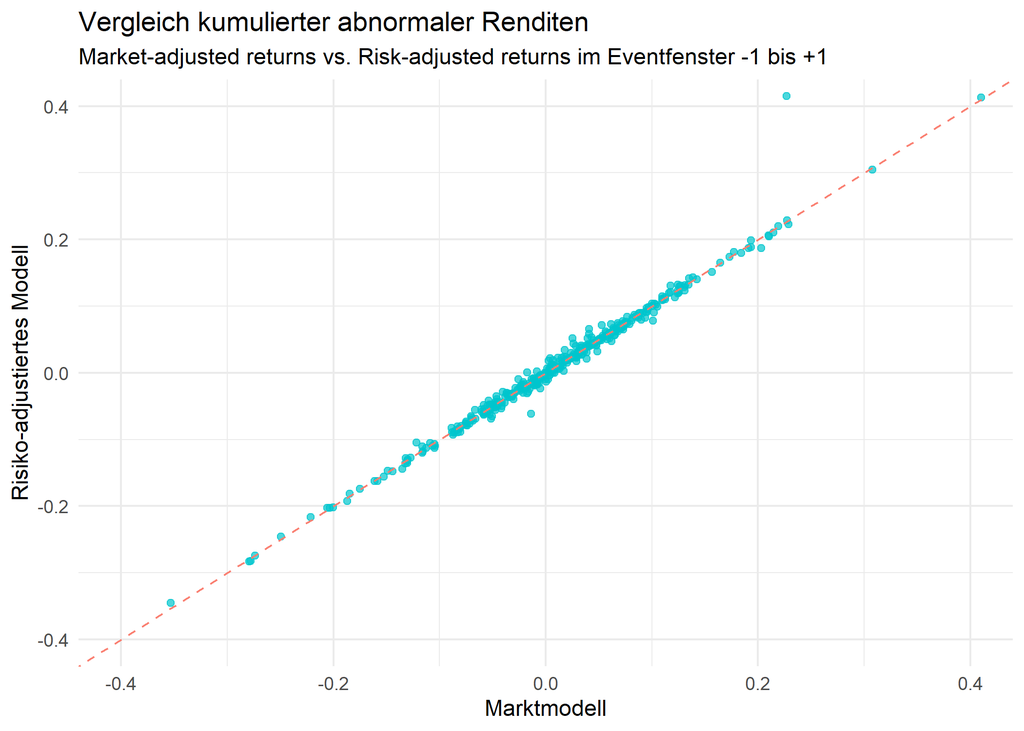

**Beschreibung**

Die Grafik zeigt einen Scatterplot, in dem die kumulierten abnormalen Renditen aus dem Market-Adjusted Returns Modell (car_101) auf der x-Achse den kumulierten abnormalen Renditen aus dem Risk-adjusted Returns Modell (cmar_101) auf der y-Achse gegenübergestellt werden. Die eingezeichnete 45-Grad-Linie dient als Referenzlinie für eine theoretisch perfekte Übereinstimmung der kumulierten abnormalen Renditen beider Modelle.

**Unterschiede zwischen den kumulierten abnormalen Renditen**

Der Vergleich der kumulierten abnormalen Renditen aus dem Market-adjusted Returns Modell (car_101) und dem Risk-adjusted Returns Modell (cmar_101) zeigt, dass die Unterschiede zwischen den aus beiden Modellen hervorgehenden Werte, ausgenommen einzelner Ausreißer, gering sind. Die meisten beobachteten Punkte liegen entlang der 45-Grad-Linie, mit relativ geringer Streuung. Die vereinzelten Abweichungen scheinen nicht systematisch und stellen somit Ausreißer dar. Insgesamt sind damit die Unterschiede in den Ergebnissen, die beide Modelle liefern geringfügig, was nahelegt, dass beide zum Zweck dieser Eventanalyse gleichermaßen geeignet sind.

**Ursachen**

Die beobachtete hohe Übereinstimmung beider Modelle lässt sich dadurch erklären, dass die Rendite des Marktindex kurzfristig eine gute Näherung für die erwartete Rendite der einzelnen darin enthaltenen Aktien ist. Das Risk-adjusted Modell prognostiziert, mithilfe einer Regression, die durchschnittliche erwartete Rendite der einzelnen Aktien basierend auf dem CAPM-Modell. Die Parameter des Modells basieren dabei auf einer Schätzperiode von in diesem Fall 120 Tagen bis 10 Tagen vor Event. Dieses Modell sollte präzisere Ergebnisse liefern, als die reine Betrachtung des Marktindex, da hier die individuelle Korrelation der einzelnen Aktienrenditen mit der Marktrendite berücksichtigt werden. Werden jedoch lediglich kurze Zeitfenster betrachtet, wie in diesem Fall 3, bzw. 10 Tage, ist der Unterschied der durch das Regressionsmodell vorhergesagten Aktienrendite zu der Marktrendite vernachlässigbar klein.

**Fazit**

Im Market-adjusted Returns Model werden die abnormalen Renditen der einzelnen Aktien berechnet, indem die Marktrendite von der jeweiligen Aktienrendite subtrahiert wird. Innerhalb des Risk-adjusted Returns Models werden dagegen die erwarteten mithilfe des CAPM-Modells prognostiziert. Da innerhalb kurzer Zeitfenster die prognostizierte Rendite überwiegend der Marktrendite naheliegt, ist das Marked-adjusted Returns Model eine geeignete Näherung, wie die Beobachtungen dieser Grafik zeigen.

19. Erstellen Sie die Grafik von Aufgabe 14 neu.

Beschreiben und interpretieren Sie ihre Grafik. Gehen Sie auch auf folgende Fragen ein:

- Könnte es zu Problemen führen, wenn in der Schätzperiode vor dem Event ein weiterer Earnings-Conference Call enthalten ist?
  - Warum könnte dies ein Problem sein, oder warum nicht?

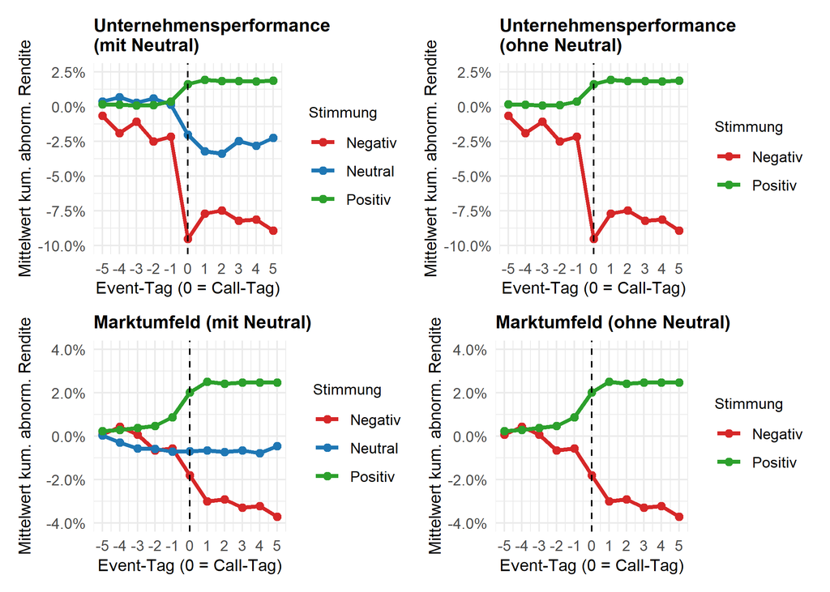

**Beschreibung der Grafiken**

Die vier Grafiken zeigen die durchschnittlichen kumulierten abnormalen Renditen (CAR) auf Basis des risiko-adjustierten Modells im Zeitraum von fünf Tagen vor bis fünf Tage nach dem Earnings Conference Call (Event-Tag 0). Analog zu Aufgabe 14 werden in den oberen beiden Grafiken die Renditeverläufe nach der Stimmung zur Unternehmensperformance dargestellt, in den unteren beiden nach der Stimmung zum allgemeinen Marktumfeld. Die Grafiken links (1 und 3) enthalten alle drei Stimmungen (positiv, neutral, negativ), während in den rechten Grafiken (2 und 4) die neutrale Kategorie weggelassen wurde. Auf der X-Achse sind die Event-Tage, auf der Y-Achse die durchschnittlichen CAR in Prozentpunkten aufgetragen. Eine gestrichelte Linie bei Tag 0 markiert den Zeitpunkt des Calls.

**Interpretation der Ergebnisse**

Die Renditeverläufe unter dem risiko-adjustierten Modell zeigen nahezu identische Muster wie unter dem einfachen Marktmodell. Bei negativer Stimmung zur Unternehmensperformance sinken die CAR am Event-Tag stark ab (ca. −10%) und bleiben niedrig. Positive Stimmung führt zu einem moderaten Anstieg (bis etwa +2%). Neutrale Äußerungen zeigen ebenfalls leicht negative Effekte (ca. −2%). Beim Marktumfeld sind die Effekte weniger ausgeprägt, aber ähnlich gerichtet: Negative Stimmung führt zu Kursverlusten von etwa −3%, positive Einschätzungen zu Gewinnen bis +2–3%. Insgesamt bestätigen die Ergebnisse die Robustheit der ursprünglichen Analyse – die risikoadjustierte Betrachtung verändert die Haupterkenntnisse nicht wesentlich.

**Probleme durch weitere Earnings Calls in der Schätzperiode**

Enthält das Schätzfenster einen weiteren Earnings Call desselben Unternehmens, kann dies problematisch sein. In diesem Fall fließt bereits eine potenziell renditeverändernde Information in die Regressionsschätzung (Beta, Alpha) ein, wodurch die erwartete „normale“ Rendite verzerrt wird. Das wiederum beeinflusst die Berechnung der abnormalen Rendite im Eventfenster. Idealerweise sollten Schätzfenster von solchen Ereignissen bereinigt sein, um unbeeinflusste Parameter zu garantieren. In der Praxis lässt sich dies aber nicht immer vermeiden – insbesondere bei großen Datensätzen oder kurzen Abständen zwischen den Calls. Ein solcher Effekt könnte erklären, warum das CAPM im Ergebnis kaum Abweichungen zum Marktmodell zeigt.

20. Lesen Sie das Kapitel [“Fixed Effects” in Huntington-Klein (2021)](https://theeffectbook.net/ch-FixedEffects.html#how-does-it-work), speziell Kapitel 16.1
21. Regressieren Sie die `cmar_101` auf die Variablen *negativ_firm* und *negativ_market* und kontrollieren Sie auf die Größe des jeweiligen Unternehmens, indem Sie die Variable *Total_Assets* in ihre Regression aufnehmen. Kontrollieren Sie weiterhin auf das Jahr in dem das Event stattgefunden hat. Fügen Sie weiterhin der Regression Firmen-Fixe Effekte hinzu.

Beschreiben und interpretieren Sie ihre Ergebnisse.

Gehen Sie zusätzlich auf die folgenden Frage ein:

- Was sind Firmen-Fixe Effekte und warum könnten diese für ihre Regression sinnvoll sein?

*Hinweis:* Mit dem [Paket `fixest`](https://cran.r-project.org/web/packages/fixest/vignettes/fixest_walkthrough.html) und der Funktion feols() können Sie einfach ihren Regressionen fixe Effekte hinzufügen

|  | Abhängige Variable: kumulierte Risiko-adjustierte abnormale Renditen Negativ | Abhängige Variable: kumulierte Risiko-adjustierte abnormale Renditen Negativ mit Jahreskontrollen | Abhängige Variable: kumulierte Risiko-adjustierte abnormale Renditen Negativ mit Firmenfixen Effekten |
| --- | --- | --- | --- |
| Negative Firmfaktoren | -0.029 | -0.028 | -0.020 |
|  | (0.027) | (0.023) | (0.019) |
| Negativer Markt | -0.056* | -0.054 | -0.052* |
|  | (0.022) | (0.032) | (0.019) |
| Total Assets | 0.000 | 0.000 | 0.000 |
|  | (0.000) | (0.000) | (0.000) |
| Num.Obs. | 362 | 362 | 362 |
| AIC | -719.6 | -712.9 | -676.1 |
| BIC | -704.0 | -677.8 | -532.1 |
| Std.Errors | IID | by: jahr | by: jahr |

* p < 0.05, ** p < 0.01, *** p < 0.001

**Beschreibung**

Die Tabelle zeigt die Ergebnisse von drei Regressionsmodellen, die den Einfluss negativer Stimmungsfaktoren auf die kumulierten Risiko-adjustierten abnormalen Renditen untersuchen. Das erste Modell betrachtet die Übermittlung negative Firmenfaktoren und negativer Marktzustände ohne zusätzliche Kontrollen. Im zweiten Modell werden zusätzlich für Jahres-Fixe Effekte kontrolliert. Das dritte Modell erweitert diese Analyse schließlich um Firmen-Fixe Effekte, mit dem Zweck unternehmensspezifische Einflüsse herauszurechnen und die Effektschätzungen zu präzisieren. In allen drei Modellen wurde zusätzlich auf die Unternehmensgröße kontrolliert (Total Assets).

Die Koeffizienten der erklärenden Variablen, sowie der Kontrollvariablen, weisen in diesem Modell ähnliche Größenordnungen auf, wie in der Regression auf die Markt-adjustierten abnormalen Renditen in Aufgabe 16, unterscheiden sich jedoch teilweise in ihrer Signifikanz.

Bei Kontrolle auf das Geschäftsjahr ändert sich die Koeffizienten der erklärenden Variablen nur geringfügig. Der Effekt einer negativen Marktstimmung verringert verliert jedoch an Signifikanz.

**Interpretation**

Die Ergebnisse legen nahe, dass ein negativer Ton in der Übermittlung von Firmenfaktoren in den Earnings Conference Calls, keinen signifikanten Einfluss auf die kumulierten risikoadjustierten abnormalen Renditen haben. Dies deutet darauf hin, dass sich negative Aussagen im Firmensentiment allein nicht signifikant auf die Renditen auswirken. Dies deckt sich mit den Ergebnissen der Regression aus Aufgabe 16.

Der negative Marktfaktor zeigt im ersten Modell einen signifikanten negativen Effekt, verliert jedoch bei Kontrolle auf Jahresfixe Effekte an Signifikanz, wird jedoch im dritten Modell mit Firmen-Fixen Effekten wieder signifikant negativ. In Kombination mit den Erkenntnissen aus Aufgabe 16, sprechen die Beobachtungen dafür, dass negative Marktsignale im Zusammenspiel mit firmenspezifischen Unterschieden durchaus relevant für Anlegerreaktionen sind, wahrscheinlich jedoch hohe Varianzen aufweisen, die dafür sorgen, dass die Signifikanz des Effektes nicht unter allen Modellbedingungen stabil bleibt. Da jedoch in der Mehrheit der Fälle ein mindestens 5%-iges Signifikanzniveau vorliegt, ist ein systematischer Effekt wahrscheinlicher als ein zufälliger Effekt.

Die Variable Total Assets zeigt in allen Modellen einen sehr kleinen, insignifikanten Koeffizienten nahe null, was darauf hinweist, dass die Firmengröße in diesem Datensatz keinen relevanten Einfluss auf die abnormalen Renditen im Ereigniszeitraum ausübt.

Insgesamt zeigen die Ergebnisse, dass der negative Marktfaktor eine stärkere Rolle für Renditen spielt als negative firmenspezifische Faktoren. Firmen- und Jahres-Fixe Effekte helfen dabei, die Robustheit der Schätzergebnisse zu überprüfen und sicherzustellen, dass die Schätzergebnisse nicht durch unbeobachtete firmenspezifische, oder geschäftsperiodenbedingte Faktoren verzerrt werden.

**Was sind Firmen-Fixe Effekte und warum könnten diese für ihre Regression sinnvoll sein?**

Firmen-Fixe Effekte kontrollieren für alle firmenspezifischen Merkmale, die über den Betrachtungszeitraum der vorliegenden Daten hinweg konstant bleiben. Faktoren wie die Marktstellung, das Wettbewerbsverhalten oder die finanzielle Lage eines Unternehmens könnten einerseits die Stimmung in deren Earnings-Conference-Calls beeinflussen und andererseits die Sensitivität der Anleger auf negative Signale erhöhen. Eine Firma mit hoher Verschuldung könnte eher zu einem vorsichtigen Ton neigen, während zugleich Anleger aufgrund des Verschuldungsgrades sensibler auf negative Anzeichen reagieren und als Folge durch schnelle Verkäufe den Aktienwert senken.

Diese firmenspezifischen Faktoren stellen somit unbeobachtete Confounder dar, und können nicht oder nur schwerlich einzeln kontrolliert werden. Durch die Kontrolle auf die jeweilige Firma (mithilfe von Dummyvariablen, die mit Funktionen wie feols() automatisch erstellt werden), wird jedoch automatisch auf all diese firmeninternen Variablen mit kontrolliert, sofern sie konstant innerhalb der Firma und des betrachteten Zeitraums sind. Somit können durch Kontrolle auf die jeweilige Firma, Effekte die durch Unterschiede zwischen den Firmen im Datensatz zustande kommen (“**Between variation**”) herausgerechnet werden und stattdessen isoliert die Variation der Datenpunkte unabhängig der Firmensituation betrachtet werden (“**within variation**”).

# Literatur

- Kapitel Event Studies im Buch [The Effect Book: Event Studies](https://theeffectbook.net/ch-EventStudies.html)
- Kapitel Fixe Effekte im Buch [The Effect Book: Event Studies](https://theeffectbook.net/ch-FixedEffects.html)
- [Paket `fixest`](https://cran.r-project.org/web/packages/fixest/vignettes/fixest_walkthrough.html)

# Anhang

## Prompt Arten

Prompt-Arten unterscheiden sich in der Anzahl der Beispiele, die Sie dem KI-Modell geben:

**Zero-Shot Prompt**

- Keine Beispiele gegeben
- Nur die Aufgabe wird beschrieben
- Beispiel: “Übersetze ins Englische: Guten Morgen”

**One-Shot Prompt**

- Ein einziges Beispiel wird gezeigt
- Das Modell lernt aus diesem einen Beispiel
- Beispiel: “Übersetze ins Englische:

Guten Tag → Good day Guten Morgen → ?”

**Few-Shot Prompt**

- Mehrere Beispiele werden gegeben (typisch 2-5)
- Das Modell kann aus mehreren Mustern lernen
- Beispiel: “Übersetze ins Englische:

Guten Tag → Good day Auf Wiedersehen → Goodbye Danke → Thank you Guten Morgen → ?”